# Machine Learning Project

JD Anderson

Sunday, March 22, 2015

### Overview

The purpose of this project is to use evaluate sensor data and results of people performing barbell lifts. The goal is to build a model that correctly predicts which of the five different lift types (1 correct, 4 incorrect) was performed. This is stored in the “classe” variable in the set which will be the outcome for the model predictions

The data for this project comes from http://groupware.les.inf.puc-rio.br/har and more information on the experiment and the data can be found at that source.

### Loading Packages and Data

The data is provided in two files, a training set (pml=training.csv) and a testing set against which final evaluation will be performed (pml-testing.csv). The training set is split 70/30 into separate train and validation sets for this analysis.

```r
library(caret)
library(ggplot2)
pmlTraining <- read.csv("pml-training.csv")
pmlTesting <- read.csv("pml-testing.csv")
inTrain <- createDataPartition(y=pmlTraining$classe,p=0.7,list=FALSE)
training <- pmlTraining[inTrain,]
validation <- pmlTraining[-inTrain,]
```

### Exploratory Analysis

#### Validity of Outcome variable

The first question for the training data is whether there is enough variation in the classe variable to produce a valid mode.

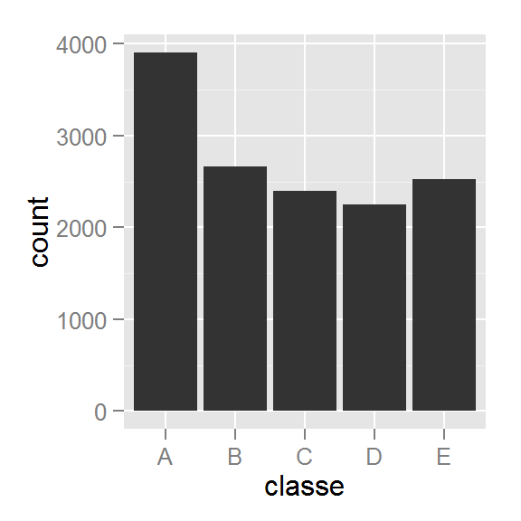

Looking at the distribution of classe, while the “A” value has a higher existence rate in the set, all of the expected results are present and in sufficient quantity to generate a model. There are also no NA valuse for the outcome.

#### Validity of the Feature Variables

There are a large set of features associated with this set (159). Paring this down to an efficient subset will need to be one of the goals for this project. The first step is this is to make sure all have data. Looking at the fill Rate for the features:

```r
FillRate<-sapply(training,function(x){sum(!is.na(x))/dim(training)[1]})
table(FillRate)
```

```
## FillRate
## 0.0200189269855136                  1
##                 67                 93
```

There are 93 fieds that are 100% populated, and 67 fields that only have values in approximately 2% of the records. These will make poor predictor values and should be safe to remove from consideration. However, this still leaves a large amount of features (92 once the Outcome is removed).

Researching the documentation from the source of the data set, it is possible to make some logical conclusions about the predictors. Based on this research, the data can be split into 3 different types: Motion Measurements (Roll, Pitch, Yaw), Direct Sensor (accelerometer, gyroscope, magenetometer), and Calculation (stdev, skew, kurtosis, etc.). Given that the Calculations are by definition derivative, they can be considered redundant information for this analysis.This leaves the Motion Measurements and Direct Sensor data as the likeliest predictor features. As it turns out, all of the NA fields fall into the Calculations category and are therefore removed by this assumption.

### Candidate Models

Having organized and reduce the features variables into groups (Motion Measurements and Sensor), a total of three candidate models can be defined; one for each group alone, and one combining the features of both.

### Model Type, Options, and Cross Validation

Given that accuracy is the primary requirement for this analysis, Random Forest was selected as the appropriate model type. While this has a performance trade-off, the work don paring down the candidate features and using parallel processing will help the run times. Since cross validation is important with Random Forests, a four-fold cross validation will also be included in each training of the models as set in the trainControl option of the train function.

### Preprocessing

```r
folds <- createFolds(training$classe,k=3,list=TRUE,returnTrain=TRUE)
MotionColumns <- c(8,9,10,46,47,48,84,85,86,122,123,124,160)
SensorColumns <- c(37:45,60:68,113:121,151:160)
CombinedColumns <- c(8:10,37:48,60:68,84:86,113:124,151:160)
```

### Model Training and Results

#### Motion Measurements

The Motion Measurements model is based on the following predictor fields: `roll_belt, pitch_belt, yaw_belt, roll_arm, pitch_arm, yaw_arm` `roll_dumbbell, pitch_dumbbell, yaw_dumbbell, roll_forearm, pitch_forearm, yaw_forearm`

##### Building the Model and Predicting against the validation set:

```r
trainMotion <- training[folds[[1]],MotionColumns]
validationMotion <- validation[,MotionColumns]
modelMotion <- train(classe~.,data=trainMotion,method="rf",trControl = trainControl(method="cv",number=4,allowParallel=TRUE))

predValidationMotion <- predict(modelMotion,validationMotion)
MotionCM <-confusionMatrix(predValidationMotion,validationMotion$classe)
MotionCM$overall[1]
```

```
## Accuracy
##   0.9837
```

```r
MotionCM$table
```

```
##           Reference
## Prediction    A    B    C    D    E
##          A 1658   10    1    0    0
##          B    4 1105    7    2    3
##          C    5   15 1007    9   10
##          D    6    6    9  952    2
##          E    1    3    2    1 1067
```

This shows that the overall accuracy of the model was approximately `98.3687`%. See Appendix Figure 1 for the full Confusion Matrix output.

#### Sensor Data

##### Building the Model and Predicting against the validation set:

```r
trainSensor <- training[folds[[2]],SensorColumns]
validationSensor <- validation[,SensorColumns]
modelSensor <- train(classe~.,data=trainSensor,method="rf",trControl = trainControl(method="cv",number=4,allowParallel=TRUE))

predValidationSensor <- predict(modelSensor,validationSensor)
SensorCM <-confusionMatrix(predValidationSensor,validationSensor$classe)
SensorCM$overall[1]
```

```
## Accuracy
##   0.9823
```

```r
SensorCM$table
```

```
##           Reference
## Prediction    A    B    C    D    E
##          A 1669   15    3    5    0
##          B    1 1110   12    0    0
##          C    0   13 1007   37    7
##          D    3    1    4  920    0
##          E    1    0    0    2 1075
```

This shows that the overall accuracy of the model was approximately `98.2328`%, which is not an improvement over the Motion model. See Appendix Figure 2 for the full Confusion Matrix output.

#### Combined Motion and Sensor

The Combined model is based on a combined set of predictors from both previous models (see above)

##### Building the Model and Predicting against the validation set:

```r
trainCombined <- training[folds[[3]],CombinedColumns]
validationCombined <- validation[,CombinedColumns]
modelCombined <- train(classe~.,data=trainCombined,method="rf",trControl = trainControl(method="cv",number=4,allowParallel=TRUE))

predValidationCombined <- predict(modelCombined,validationCombined)
CombinedCM <-confusionMatrix(predValidationCombined,validationCombined$classe)
CombinedCM$overall[1]
```

```
## Accuracy
##   0.9893
```

```r
CombinedCM$table
```

```
##           Reference
## Prediction    A    B    C    D    E
##          A 1669   13    0    0    0
##          B    1 1120    8    1    2
##          C    2    6 1011   14    6
##          D    0    0    7  948    0
##          E    2    0    0    1 1074
```

This shows that the overall accuracy of the model was approximately `98.9295`%, which exceeds both previous models. See Appendix Figure 3 for the full Confusion Matrix output.

### Final Model Selection, Training, and Error Estimation

Given the results of the three subset model tests, the Combined model was chosen for the final model based on Accuracy. Running this against the full training set produces the following results (Note Full Confusion Matrix output can be seen in Appendix Figure 4):

```r
trainFinal <- training[,CombinedColumns]
validationFinal <- validation[,CombinedColumns]
modelFinal <- train(classe~.,data=trainFinal,method="rf",trControl = trainControl(method="cv",number=4,allowParallel=TRUE))
```

#### Training set (in sample results)

```r
predTrainFinal <- predict(modelFinal,trainFinal)
FinalTrainCM <- confusionMatrix(predTrainFinal,trainFinal$classe)
FinalTrainCM$overall[1]
```

```
## Accuracy
##        1
```

```r
FinalTrainCM$table
```

```
##           Reference
## Prediction    A    B    C    D    E
##          A 3906    0    0    0    0
##          B    0 2658    0    0    0
##          C    0    0 2396    0    0
##          D    0    0    0 2252    0
##          E    0    0    0    0 2525
```

#### Validation Set (out of sample error estimate)

```r
predValidationFinal <- predict(modelFinal,validationFinal)
FinalValidationCM <- confusionMatrix(predValidationFinal,validationFinal$classe)
FinalValidationCM$overall[1]
```

```
## Accuracy
##   0.9946
```

```r
FinalValidationCM$table
```

```
##           Reference
## Prediction    A    B    C    D    E
##          A 1671    8    0    0    0
##          B    0 1129    6    0    0
##          C    1    2 1018    4    5
##          D    0    0    2  959    1
##          E    2    0    0    1 1076
```

This shows and In Sample accuracy (based on the training set) of `100`% and an Out of Sample accuracy (based on the validation set) of `99.4562`%.

### Final Results

The final model, when applied against the provided Test set and submitted scored 20 out of 20.

## Appendix

#### Figure 1: Motion Measurements Test Prediction Confusion Matrix

```r
MotionCM
```

```
## Confusion Matrix and Statistics
##
##           Reference
## Prediction    A    B    C    D    E
##          A 1658   10    1    0    0
##          B    4 1105    7    2    3
##          C    5   15 1007    9   10
##          D    6    6    9  952    2
##          E    1    3    2    1 1067
##
## Overall Statistics
##
##                Accuracy : 0.984
##                  95% CI : (0.98, 0.987)
##     No Information Rate : 0.284
##     P-Value [Acc > NIR] : <2e-16
##
##                   Kappa : 0.979
##  Mcnemar's Test P-Value : 0.0115
##
## Statistics by Class:
##
##                      Class: A Class: B Class: C Class: D Class: E
## Sensitivity             0.990    0.970    0.981    0.988    0.986
## Specificity             0.997    0.997    0.992    0.995    0.999
## Pos Pred Value          0.993    0.986    0.963    0.976    0.993
## Neg Pred Value          0.996    0.993    0.996    0.998    0.997
## Prevalence              0.284    0.194    0.174    0.164    0.184
## Detection Rate          0.282    0.188    0.171    0.162    0.181
## Detection Prevalence    0.284    0.190    0.178    0.166    0.182
## Balanced Accuracy       0.994    0.983    0.987    0.991    0.992
```

#### Figure 2: Sensor Measurements Test Prediction Confusion Matrix

```r
SensorCM
```

```
## Confusion Matrix and Statistics
##
##           Reference
## Prediction    A    B    C    D    E
##          A 1669   15    3    5    0
##          B    1 1110   12    0    0
##          C    0   13 1007   37    7
##          D    3    1    4  920    0
##          E    1    0    0    2 1075
##
## Overall Statistics
##
##                Accuracy : 0.982
##                  95% CI : (0.979, 0.986)
##     No Information Rate : 0.284
##     P-Value [Acc > NIR] : <2e-16
##
##                   Kappa : 0.978
##  Mcnemar's Test P-Value : NA
##
## Statistics by Class:
##
##                      Class: A Class: B Class: C Class: D Class: E
## Sensitivity             0.997    0.975    0.981    0.954    0.994
## Specificity             0.995    0.997    0.988    0.998    0.999
## Pos Pred Value          0.986    0.988    0.946    0.991    0.997
## Neg Pred Value          0.999    0.994    0.996    0.991    0.999
## Prevalence              0.284    0.194    0.174    0.164    0.184
## Detection Rate          0.284    0.189    0.171    0.156    0.183
## Detection Prevalence    0.288    0.191    0.181    0.158    0.183
## Balanced Accuracy       0.996    0.986    0.985    0.976    0.996
```

#### Figure 3: Combined Measurements Test Prediction Confusion Matrix

```r
CombinedCM
```

```
## Confusion Matrix and Statistics
##
##           Reference
## Prediction    A    B    C    D    E
##          A 1669   13    0    0    0
##          B    1 1120    8    1    2
##          C    2    6 1011   14    6
##          D    0    0    7  948    0
##          E    2    0    0    1 1074
##
## Overall Statistics
##
##                Accuracy : 0.989
##                  95% CI : (0.986, 0.992)
##     No Information Rate : 0.284
##     P-Value [Acc > NIR] : <2e-16
##
##                   Kappa : 0.986
##  Mcnemar's Test P-Value : NA
##
## Statistics by Class:
##
##                      Class: A Class: B Class: C Class: D Class: E
## Sensitivity             0.997    0.983    0.985    0.983    0.993
## Specificity             0.997    0.997    0.994    0.999    0.999
## Pos Pred Value          0.992    0.989    0.973    0.993    0.997
## Neg Pred Value          0.999    0.996    0.997    0.997    0.998
## Prevalence              0.284    0.194    0.174    0.164    0.184
## Detection Rate          0.284    0.190    0.172    0.161    0.182
## Detection Prevalence    0.286    0.192    0.177    0.162    0.183
## Balanced Accuracy       0.997    0.990    0.990    0.991    0.996
```

#### Figure 4: Final Measurements Test Prediction Confusion Matric

```r
FinalTrainCM
```

```
## Confusion Matrix and Statistics
##
##           Reference
## Prediction    A    B    C    D    E
##          A 3906    0    0    0    0
##          B    0 2658    0    0    0
##          C    0    0 2396    0    0
##          D    0    0    0 2252    0
##          E    0    0    0    0 2525
##
## Overall Statistics
##
##                Accuracy : 1
##                  95% CI : (1, 1)
##     No Information Rate : 0.284
##     P-Value [Acc > NIR] : <2e-16
##
##                   Kappa : 1
##  Mcnemar's Test P-Value : NA
##
## Statistics by Class:
##
##                      Class: A Class: B Class: C Class: D Class: E
## Sensitivity             1.000    1.000    1.000    1.000    1.000
## Specificity             1.000    1.000    1.000    1.000    1.000
## Pos Pred Value          1.000    1.000    1.000    1.000    1.000
## Neg Pred Value          1.000    1.000    1.000    1.000    1.000
## Prevalence              0.284    0.193    0.174    0.164    0.184
## Detection Rate          0.284    0.193    0.174    0.164    0.184
## Detection Prevalence    0.284    0.193    0.174    0.164    0.184
## Balanced Accuracy       1.000    1.000    1.000    1.000    1.000
```

```r
FinalValidationCM
```

```
## Confusion Matrix and Statistics
##
##           Reference
## Prediction    A    B    C    D    E
##          A 1671    8    0    0    0
##          B    0 1129    6    0    0
##          C    1    2 1018    4    5
##          D    0    0    2  959    1
##          E    2    0    0    1 1076
##
## Overall Statistics
##
##                Accuracy : 0.995
##                  95% CI : (0.992, 0.996)
##     No Information Rate : 0.284
##     P-Value [Acc > NIR] : <2e-16
##
##                   Kappa : 0.993
##  Mcnemar's Test P-Value : NA
##
## Statistics by Class:
##
##                      Class: A Class: B Class: C Class: D Class: E
## Sensitivity             0.998    0.991    0.992    0.995    0.994
## Specificity             0.998    0.999    0.998    0.999    0.999
## Pos Pred Value          0.995    0.995    0.988    0.997    0.997
## Neg Pred Value          0.999    0.998    0.998    0.999    0.999
## Prevalence              0.284    0.194    0.174    0.164    0.184
## Detection Rate          0.284    0.192    0.173    0.163    0.183
## Detection Prevalence    0.285    0.193    0.175    0.163    0.183
## Balanced Accuracy       0.998    0.995    0.995    0.997    0.997
```